# Titanic_EDA

```python
import pandas as pd
import numpy as np
import matplotlib.pyplot as plt
import seaborn as sns

# Display graphs properly
%matplotlib inline

print("Libraries Imported Successfully!")
```

```
Libraries Imported Successfully!
```

```python
import pandas as pd

df = pd.read_csv("Titanic-Dataset.csv")

df.head()
```

[output not shown]

[output cut: 9 more lines]

[output not shown]

```python
import os
print(os.getcwd())
```

```
C:\Users\katis
```

```python
import os
print(os.listdir())
```

[output not shown]

```python
df = pd.read_csv(r"C:\Users\katis\Desktop\Titanic-Dataset.csv")
df.head()
```

[output not shown]

```python
import os

desktop_path = r"C:\Users\katis\Desktop"
print(os.listdir(desktop_path))
```

[output not shown]

```python
df = pd.read_csv(r"C:\Users\katis\Desktop\Titanic-EDA-Analysis\Titanic-Dataset.csv")
df.head()
```

[output not shown]

```python
import os

path = r"C:\Users\katis\OneDrive\Desktop\Titanic-EDA-Analysis"
print(os.listdir(path))
```

```
['data', 'images', 'New folder', 'reports']
```

```python
df = pd.read_csv(r"C:\Users\katis\OneDrive\Desktop\Titanic-EDA-Analysis\data\Titanic-Dataset.csv")
df.head()
```

|  | PassengerId | Survived | Pclass | Name | Sex | Age | SibSp | Parch | Ticket | Fare | Cabin | Embarked |
| --- | --- | --- | --- | --- | --- | --- | --- | --- | --- | --- | --- | --- |
| 0 | 1 | 0 | 3 | Braund, Mr. Owen Harris | male | 22.0 | 1 | 0 | A/5 21171 | 7.2500 | NaN | S |
| 1 | 2 | 1 | 1 | Cumings, Mrs. John Bradley (Florence Briggs Th... | female | 38.0 | 1 | 0 | PC 17599 | 71.2833 | C85 | C |
| 2 | 3 | 1 | 3 | Heikkinen, Miss. Laina | female | 26.0 | 0 | 0 | STON/O2. 3101282 | 7.9250 | NaN | S |
| 3 | 4 | 1 | 1 | Futrelle, Mrs. Jacques Heath (Lily May Peel) | female | 35.0 | 1 | 0 | 113803 | 53.1000 | C123 | S |
| 4 | 5 | 0 | 3 | Allen, Mr. William Henry | male | 35.0 | 0 | 0 | 373450 | 8.0500 | NaN | S |

```python
df.info()
```

```
<class 'pandas.DataFrame'>
RangeIndex: 891 entries, 0 to 890
Data columns (total 12 columns):
 #   Column       Non-Null Count  Dtype
---  ------       --------------  -----
 0   PassengerId  891 non-null    int64
 1   Survived     891 non-null    int64
 2   Pclass       891 non-null    int64
 3   Name         891 non-null    str
 4   Sex          891 non-null    str
 5   Age          714 non-null    float64
 6   SibSp        891 non-null    int64
 7   Parch        891 non-null    int64
 8   Ticket       891 non-null    str
 9   Fare         891 non-null    float64
 10  Cabin        204 non-null    str
 11  Embarked     889 non-null    str
dtypes: float64(2), int64(5), str(5)
memory usage: 118.9 KB
```

```python
df.describe()
```

|  | PassengerId | Survived | Pclass | Age | SibSp | Parch | Fare |
| --- | --- | --- | --- | --- | --- | --- | --- |
| count | 891.000000 | 891.000000 | 891.000000 | 714.000000 | 891.000000 | 891.000000 | 891.000000 |
| mean | 446.000000 | 0.383838 | 2.308642 | 29.699118 | 0.523008 | 0.381594 | 32.204208 |
| std | 257.353842 | 0.486592 | 0.836071 | 14.526497 | 1.102743 | 0.806057 | 49.693429 |
| min | 1.000000 | 0.000000 | 1.000000 | 0.420000 | 0.000000 | 0.000000 | 0.000000 |
| 25% | 223.500000 | 0.000000 | 2.000000 | 20.125000 | 0.000000 | 0.000000 | 7.910400 |
| 50% | 446.000000 | 0.000000 | 3.000000 | 28.000000 | 0.000000 | 0.000000 | 14.454200 |
| 75% | 668.500000 | 1.000000 | 3.000000 | 38.000000 | 1.000000 | 0.000000 | 31.000000 |
| max | 891.000000 | 1.000000 | 3.000000 | 80.000000 | 8.000000 | 6.000000 | 512.329200 |

df.isnull().sum()

Observation:

1. The dataset contains 891 records and 12 features.
2. Missing values are present in Age, Cabin, and Embarked columns.
3. Cabin contains the highest number of missing values.
4. Numerical columns include Age, Fare, SibSp, Parch, etc.

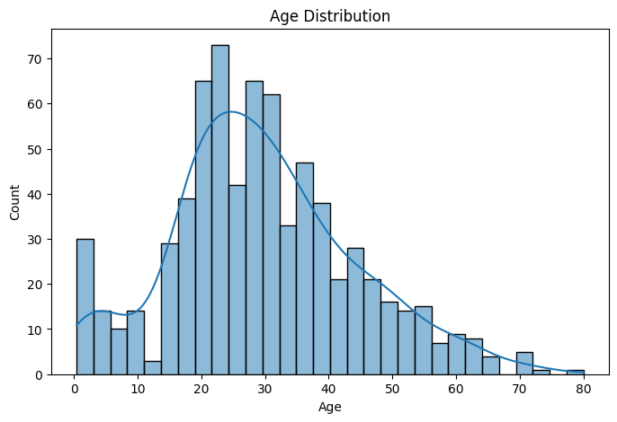

```python
import matplotlib.pyplot as plt
import seaborn as sns

plt.figure(figsize=(8,5))
sns.histplot(df['Age'], bins=30, kde=True)

plt.title('Age Distribution')
plt.xlabel('Age')
plt.ylabel('Count')

plt.show()
```

Observation:

1. Most passengers were between 20 and 40 years old.
2. The age distribution is slightly right-skewed.
3. There were fewer elderly passengers compared to adults.

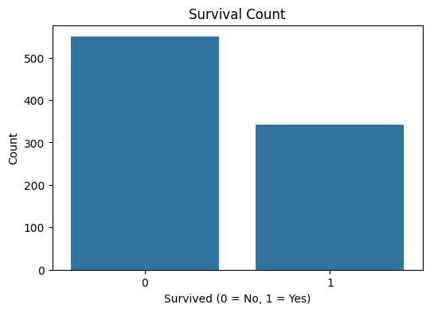

```python
plt.figure(figsize=(6,4))
sns.countplot(x='Survived', data=df)

plt.title('Survival Count')
plt.xlabel('Survived (0 = No, 1 = Yes)')
plt.ylabel('Count')

plt.show()
```

Observation:

1. More passengers died than survived.
2. The survival rate was lower than the death rate.
3. The Titanic disaster resulted in significant loss of life.

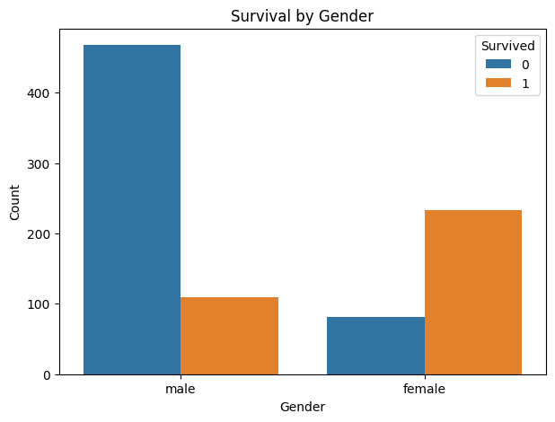

```python
plt.figure(figsize=(7,5))
sns.countplot(x='Sex', hue='Survived', data=df)

plt.title('Survival by Gender')
plt.xlabel('Gender')
plt.ylabel('Count')

plt.show()
```

Observation:

1. Female passengers had a much higher survival rate.
2. Male passengers experienced a higher mortality rate.
3. Gender appears to be an important factor affecting survival.

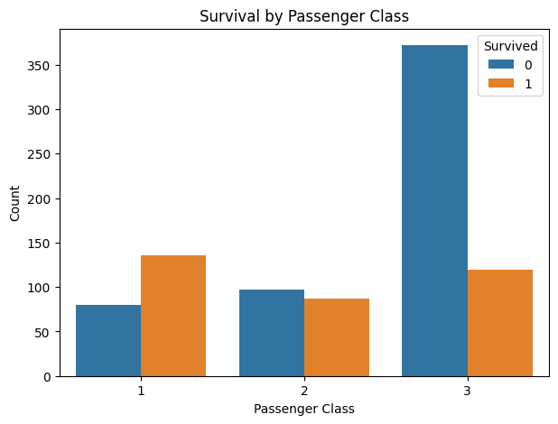

```python
plt.figure(figsize=(7,5))
sns.countplot(x='Pclass', hue='Survived', data=df)

plt.title('Survival by Passenger Class')
plt.xlabel('Passenger Class')
plt.ylabel('Count')

plt.show()
```

Observation:

1. First-class passengers had the highest survival rate.
2. Third-class passengers experienced the highest mortality rate.
3. Passenger class had a significant impact on survival chances.

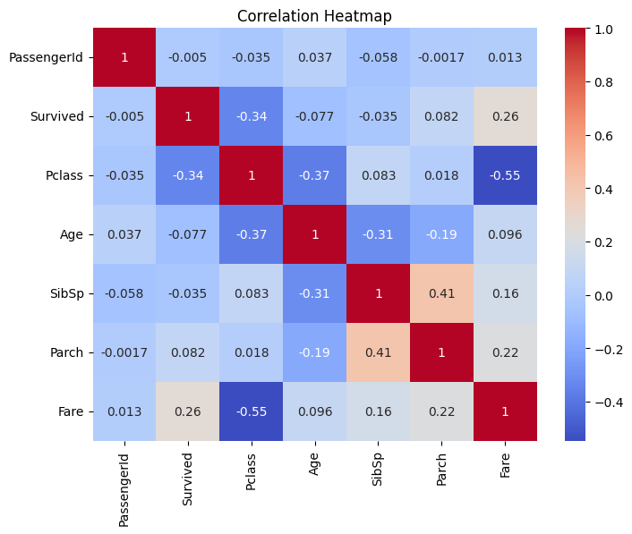

```python
plt.figure(figsize=(8,6))

numeric_df = df.select_dtypes(include='number')

sns.heatmap(
    numeric_df.corr(),
    annot=True,
    cmap='coolwarm'
)

plt.title('Correlation Heatmap')
plt.show()
```

Observation:

1. Survival has a positive correlation with Fare.
2. Survival has a negative correlation with Pclass.
3. Fare and Pclass are negatively correlated.
4. Age shows a weak correlation with Survival.

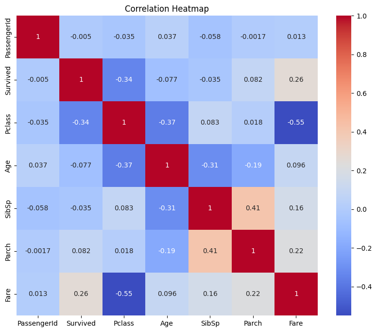

```python
plt.figure(figsize=(10,8))

numeric_df = df.select_dtypes(include='number')

sns.heatmap(
    numeric_df.corr(),
    annot=True,
    cmap='coolwarm'
)

plt.title('Correlation Heatmap')
plt.show()
```

Observation:

1. Survival has a positive correlation with Fare.
2. Survival has a negative correlation with Passenger Class (Pclass).
3. Fare and Pclass are negatively correlated.
4. Age has a weak correlation with Survival.
5. No strong multicollinearity is observed among numerical features.

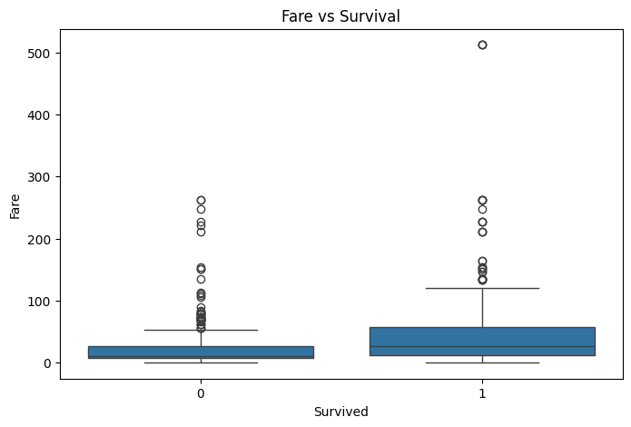

```python
plt.figure(figsize=(8,5))

sns.boxplot(
    x='Survived',
    y='Fare',
    data=df
)

plt.title('Fare vs Survival')
plt.xlabel('Survived')
plt.ylabel('Fare')

plt.show()
```

Observation:

1. Survivors generally paid higher fares.
2. Higher ticket fare appears to be associated with better survival chances.
3. Several outliers exist in the Fare column.

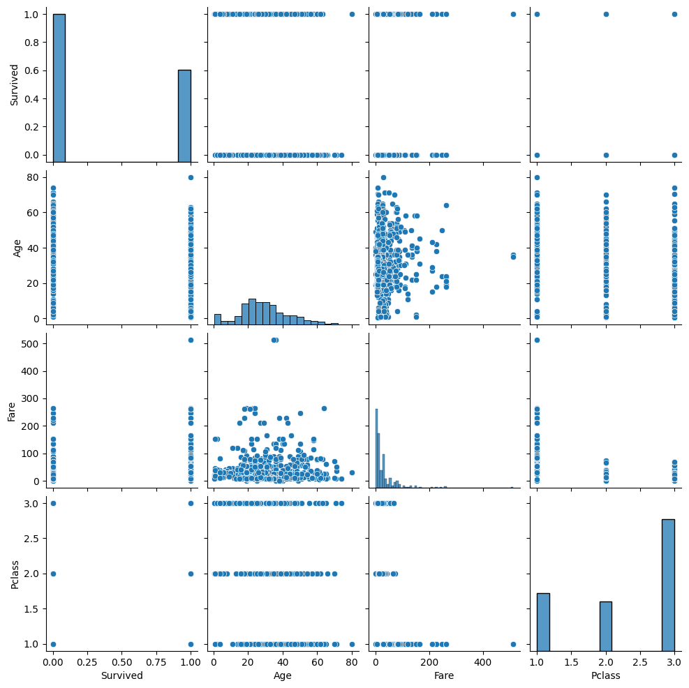

```python
sns.pairplot(
    df[['Survived','Age','Fare','Pclass']]
)

plt.show()
```

Observation:

1. Fare and Passenger Class show a noticeable relationship.
2. Survival is more closely related to Fare and Pclass than Age.
3. Age does not show a strong separation between survivors and non-survivors.

```python
df['Survived'].value_counts()
```

```
Survived
0    549
1    342
Name: count, dtype: int64
```

Observation:

1. More passengers did not survive than survived.
2. Most passengers belonged to the third passenger class.

Summary of Findings

1. The dataset contains 891 records and 12 features.
2. Missing values were found in Age, Cabin, and Embarked columns.
3. Female passengers had significantly higher survival rates than males.
4. First-class passengers were more likely to survive.
5. Third-class passengers experienced the highest mortality rate.
6. Higher ticket fares were associated with better survival chances.
7. Most passengers were between 20 and 40 years old.
8. Age had a weaker impact on survival compared to Gender and Passenger Class.
9. Passenger Class and Fare were important factors affecting survival.